# DIFICULTAD DE LOS ALUMNOS DE INGENIERÍA EN SISTEMAS PARA SER ACEPTADOS EN SU PRIMERA OPCIÓN DE PRÁCTICA PROFESIONAL

Leonardo Flores

17/5/2020

## 1. Introducción

En este análisis tratamos de mostrar cuales son algunas de las razones o causas por las cuales los estudiantes de la carrera de ingeniería en sistemas de la UNAH pueden llegar a ser rechazados al momento de aplicar a un trabajo o su práctica profesional. La recolección de estos datos se hizo mediante la aplicación de encuestas a los mismos estudiantes. Se conoce que para estos estudiantes es de suma importancia la realización de la práctica profesional y posteriormente la obtención de un trabajo, por lo que en este estudio se trata de mostrar cual sería una posible solución mediante la implementación de tecnología para preenir situaciones de rechazo y asi aumentar los casos de éxito en lo que actualmente es una problemática por la que muchos estudiantes se ven afectados.

## 2. Variables capturadas

```
## 'data.frame':    44 obs. of  23 variables:
##  $ edad                          : chr  "20-25" "26-30" "20-25" "20-25" ...
##  $ genero                        : chr  "Masculino" "Masculino" "Masculino" "Masculino" ...
##  $ estudiante_foraneo            : chr  "No" "No" "Si" "Si" ...
##  $ trabaja                       : chr  "No (si su respuesta es \"No\" puede dar clic en siguiente)" "No (si su respuesta es \"No\" puede dar clic en siguiente)" "No (si su respuesta es \"No\" puede dar clic en siguiente)" "si" ...
##  $ rubro_trabajo                 : chr  "" "" "" "Si" ...
##  $ practica_actualmente          : chr  "No (si su respuesta es \"No\" puede dar clic en siguiente)" "No (si su respuesta es \"No\" puede dar clic en siguiente)" "No (si su respuesta es \"No\" puede dar clic en siguiente)" "Si" ...
##  $ rango_indice                  : chr  "76-80" "76-80" "76-80" "71-75" ...
##  $ rendimiento_academico         : chr  "Medio" "Medio" "Bajo" "Medio" ...
##  $ nuevas_habilidades_autodidacta: chr  "Si" "Si" "Si" "Si" ...
##  $ hora_investigacion            : chr  "4-5 horas" "4-5 horas" "1-3 horas" "4-5 horas" ...
##  $ entrevistas_previas           : chr  "Mas de una vez" "Mas de una vez" "Una vez" "Una vez" ...
##  $ rechazo_en_entrevista         : chr  "No" "No" "No" "No" ...
##  $ area_sistema_dominada         : chr  "Base de datos;Infraestructura" "Base de datos" "Desarrollo" "Desarrollo;Base de datos;Infraestructura;Lo que se venga" ...
##  $ area_sistema_dificulta        : chr  "Desarrollo" "Desarrollo" "Base de datos" "Electrónica " ...
##  $ empresa_segun_actividad       : chr  "Proveedoras de servicios o mantenimiento" "Bancos" "Ventas y desarrollo de software" "Bancos" ...
##  $ area_preferida                : chr  "Bases de datos" "Bases de datos" "Desarrollo de software" "Desarrollo de software" ...
##  $ info_sobre_empresa            : chr  "Poco" "Poco" "Poco" "Poco" ...
##  $ importancia_uso_tecnologia    : chr  "Mucha importancia" "Mucha importancia" "Mucha importancia" "Mucha importancia" ...
##  $ acceso_ofertas                : chr  "Sí" "Sí" "Sí" "Sí" ...
##  $ ofertas_exclusivas_estudiantes: chr  "Sí" "Sí" "Sí" "Sí" ...
##  $ notificacion_oferta           : chr  "Sí" "Sí" "Sí" "Sí" ...
##  $ estado_estudiante             : chr  "no hace practica" "no hace practica" "no hace practica" "Si hace practica en su primera opcion" ...
##  $ clases_durante_practica       : chr  "no hace practica" "no hace practica" "no hace practica" "Si cursa clases durante practica" ...
```

Como se puede observar se capturaron 44 observaciones y 23 columnas, estas fueron diseñadas en función de las siguientes categorías:

1. Demográficas
2. Datos académicos
3. Hábitos del estudiante
4. Experiencias previas
5. Hardskills
6. Área de la empresa
7. Solución tecnológica

A continuación se muestra un resumen rápido de nuestras columnas; se debe tener en cuenta que, la información recopilada en nuestra encuesta se basa en variables categóricas por lo que este resumen no tiene datos con relevancia numérica estadística, sin embargo las variables han sido tratadas por separado, y en la sección de análisis descriptivo de datos se puede observar el tratamiento de dichas variables para la obtención de los datos estadísticos de utilidad.

```
##        edad          genero   estudiante_foraneo
##  20-25   :25   Femenino :13   No:34
##  26-30   :17   Masculino:31   Si:10
##  31 o Mas: 2
##
##
##
##
##                                                      trabaja   rubro_trabajo
##  No (si su respuesta es "No" puede dar clic en siguiente):25     :23
##  si                                                      :19   No: 8
##                                                                Si:13
##
##
##
##
##                                                practica_actualmente
##  No (si su respuesta es "No" puede dar clic en siguiente):35
##  Si                                                      : 9
##
##
##
##
##
##    rango_indice rendimiento_academico nuevas_habilidades_autodidacta
##  66-70   : 6    Alto :11              No: 1
##  71-75   :12    Bajo : 1              Si:43
##  76-80   :14    Medio:32
##  81 o mas:12
##
##
##
##      hora_investigacion     entrevistas_previas rechazo_en_entrevista
##  1-3 horas    :18       Mas de una vez:22       No:30
##  4-5 horas    :17       nunca         :11       Si:14
##  5 o mas horas: 9       Una vez       :11
##
##
##
##
```

[output cut: 33 more lines]

```
##  No: 2               no hace practica                     :31
##  Sí:42               No hace practica en su primera opcion:10
##                      Si hace practica en su primera opcion: 3
##
##
##
##
##                      clases_durante_practica
##  No cursa clases durante practica: 3
##  no hace practica                :31
##  Si cursa clases durante practica:10
##
##
##
##
```

## 3. Tratamiento de columnas

El principal tratamiento que se hizo fue a las observaciones con registros vacíos, en otras encuestas se pueden encontrar datos NA sin necesitar de algún tratamiento, sin embargo en nuestra encuesta no se encontró ningun dato NA, pero posteriormente se convirteron a NA para hacer las respectivas transformaciones.

En el dataset, se encontraron los siguientes valores vacíos:

### 3.1 Para la variable rubro_trabajo se encontró lo siguiente

```
##   Var1     Freq
## 1      52.27273
## 2   No 18.18182
## 3   Si 29.54545
```

Se puede observar que existen tres niveles en la columna Var1 de la variable rubro_trabajo, con un valor vacío y una frecuencia de 52.27%

### 3.2 Para la variable practica_primera_opcion se encontró lo siguiente:

```
##   Var1      Freq
## 1      70.454545
## 2   No 22.727273
## 3   Si  6.818182
```

Se puede observar que existen tres niveles en la columna Var1 de la variable practica_primera_opcion, con un valor vacío y una frecuencia de 70.45%

### 3.3 para la variable practica_cursando clases

```
##   Var1      Freq
## 1      70.454545
## 2   No  6.818182
## 3   Si 22.727273
```

Se puede observar que existen tres niveles en la columna Var1 de la variable practica_cursando_clases, con un valor vacío y una frecuencia de 70.45%

### 3.4 Tratamiento de practica_primera_opcion:

Como se pudo observar en la tabla generada de la varible práctica primera opcion, se obtuvo un valor de 70.45% de valores vacíos, se procede a pasar esos datos vacíos a NA´s, los cuales se trabajan con una funcion de R para poder asignarles un valor.

Ese valor vacío que corresponde a los estudiantes que no realizan práctica profesional, se llena con la descripción “No hace práctica” y la columna llamada practica_primera_opcion se cambia por estado_estudiante.

En otras palabras, se realizó unaa serie de imputaciones:

El valor vacío, se llenó con “No hace práctica” No: “no hace practica en su primera opción” Si: “Si hace práctica en su primera opción”

```
##                                    Var1      Freq
## 1                      no hace practica 70.454545
## 2 No hace practica en su primera opcion 22.727273
## 3 Si hace practica en su primera opcion  6.818182
```

### 3.4 Tratamiento practica_cursando_clases

```
##                               Var1      Freq
## 1 No cursa clases durante practica  6.818182
## 2                 no hace practica 70.454545
## 3 Si cursa clases durante practica 22.727273
```

Como se pudo observar en la tabla generada de la varible practica_cursando_clases, se obtuvo un valor de 70.45% de valores vacíos, se procede a pasar esos datos vacíos a NA´s, los cuales se trabajan con una funcion de R para poder asignarles un valor.

En otras palabras, se realizó unaa serie de imputaciones:

El valor vacío, se llenó con “No hace práctica” No: “no cursa clases durante práctica” Si: “Si cursa clases durante práctica”

## 4. Analisis descriptivo de estado_estudiante.

### 4.1 El siguiente análisis descriptivo se hará sobre la variable estado_estudiante.

Esta variable captura si el estudiante que realiza práctica profesional, lo hace en el lugar de su primera elección.

boxplot:

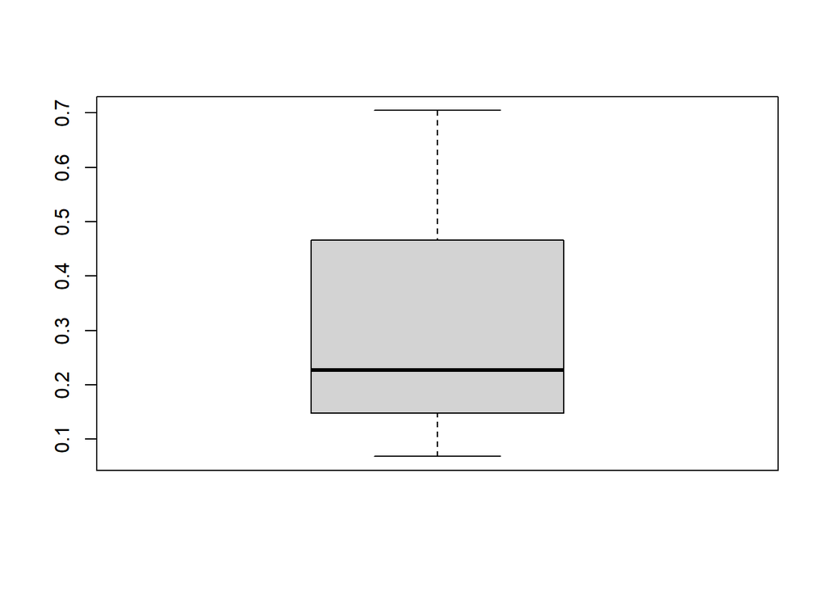

El gráfico boxplot de estado_estudiante, donde se puede observar que la mediana se encuentra en 22.72% aproximadamente, teniendo como datos mínimos y máximos un 6.83% y 70.45% respectivamente, la mayoría de los datos están dispersos en tercer y cuarto cuartil

Gráfico de barra:

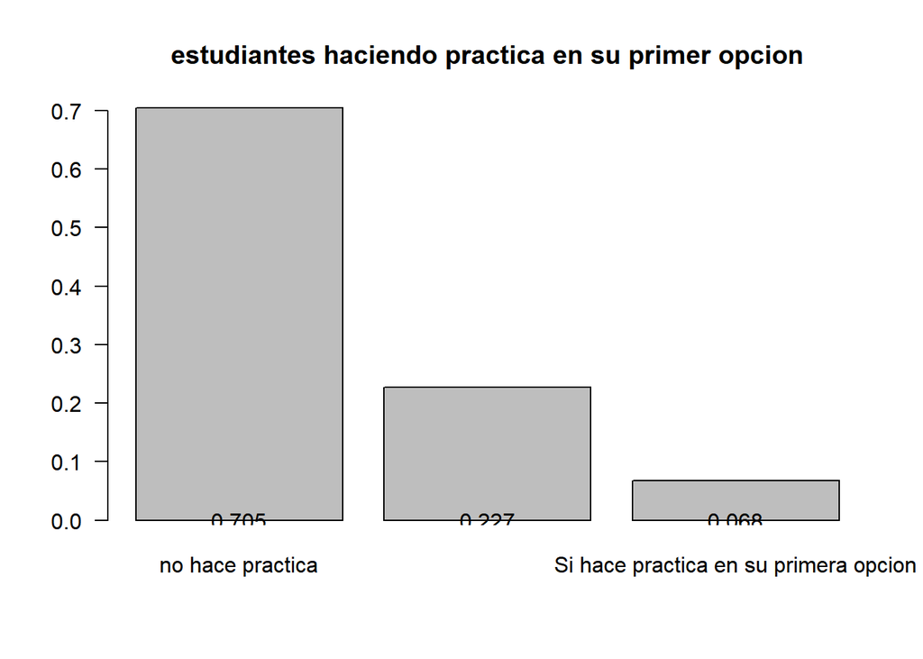

En la figura anterior está representado el estado de los estudiantes, si están realizando la práctica profesional, en caso de ser así, se evalúa si los estudiantes también realizan la práctica profesional en el centro laboral que ellos determinaron como su primera opción, y también se observa la cantidad de estudiantes que no lograron ingresar en su primera opción.

Se observa que el aproximadamente, el 70% no hace práctica, un 22% no hace práctica en el lugar de su primer elección, y solo el 6% realiza práctica profesional en el lugar de su primera elección.

QQNorm:

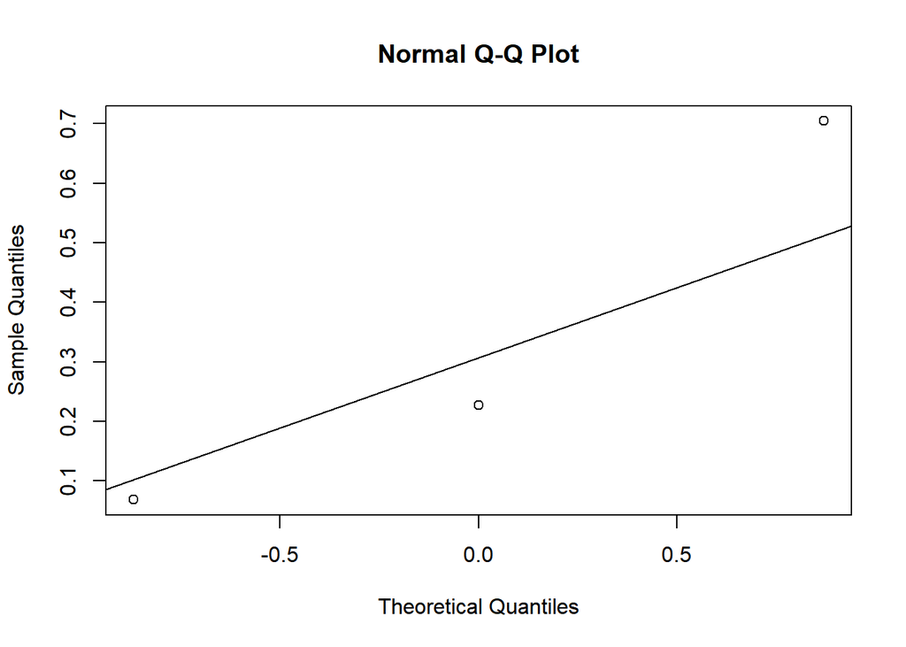

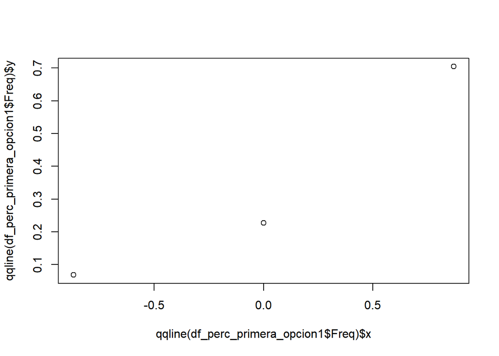

En las figuras está representada la distribución de los datos, con la línea que se ha trazado se determina la normalidad, en la cual se puede observar, que en el primer punto, de izquierda a derecha, está más cerca de la línea, este punto determina los estudiantes que si realizan la práctica profesional en el lugar deseado en primera opción, lo cual nos dice que aparentemente no hay un alto margen de error, siguiendo con el segundo punto, se empieza a alejar, este punto representa los estudiantes que no lograron acertar en su opción empresarial, y el último punto, el más alejado de la línea son los estudiantes que no realizan la práctica profesional, se puede observar la lejanía del punto respecto a la línea, esto dictaría un alto grado de error en cuanto a la distribución de los datos.

### 4.2 El siguiente análisis descriptivo se hará sobre la variable clases_durante_practica:

Esta variable analiza si el estudiante que realiza práctica profesional, cursa clases simultaneamente.

Boxplot:

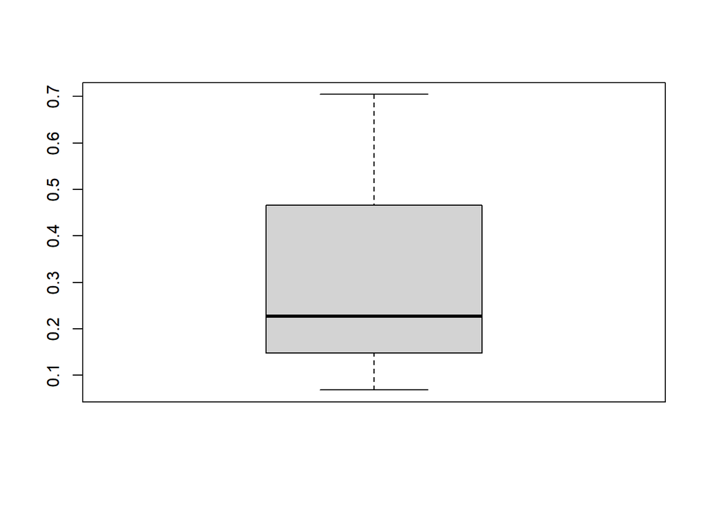

los valores del boxplot anterior están muy similares a los de la variable anterior, lo que representa este gráfico es lo siguiente, se observa que su punto mínimo es un 6.83% el cual representa a los estudiantes que realizan práctica profesional y no cursan clases simultáneamente, su punto máximo 70.45% representa aquellos estudiantes que no están realizando práctica profesional, y en su mediana, ubicada en el 22.72% son aquellos estudiantes que cursan clases realizando la labor de la práctica profesional.

Gráfico de barra:

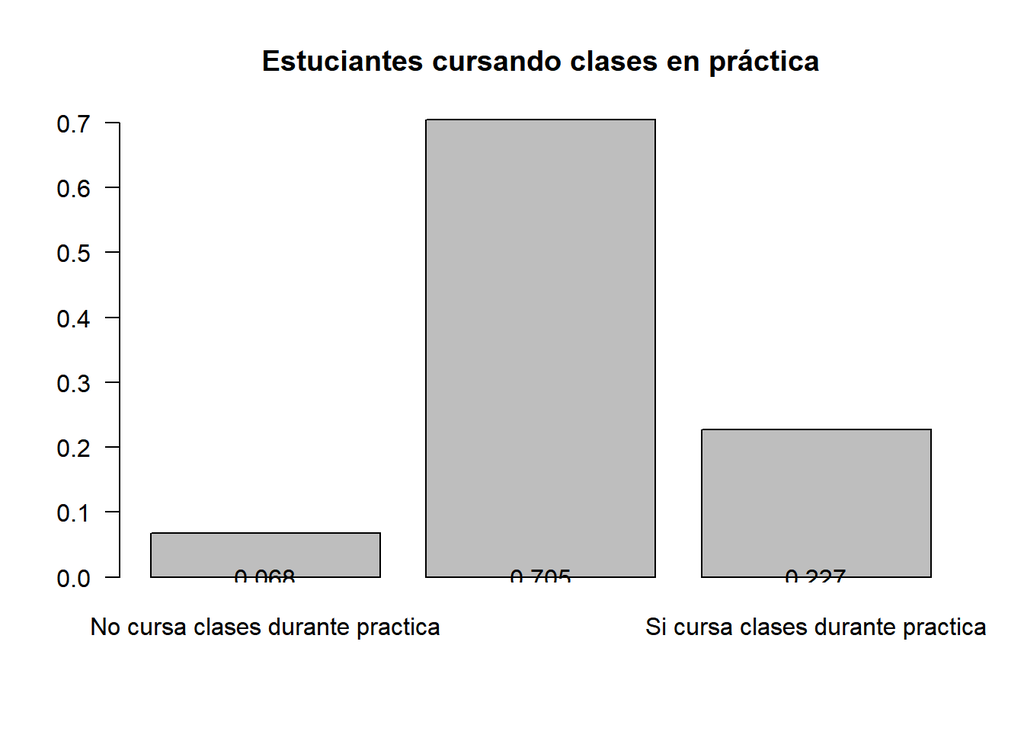

En la figura anterior observamos de una forma gráfica la distribución de los estudiantes que realizan práctica profesional cursando o no clases simultáneamente, y los estudiantes que no realizan práctica profesional,como se había mencionado anteriormente de la similitud en los valores de estas variables se debe a la dependencia que estas variables (estado_estudiante y clases_durante_practca) tienen respecto a la variable (practica_actualmente), claramente se observa que las dos variables mencionadas anteriormente trabajan dándole mayor importancia a los estudiantes que respondieron que si realizan práctica actualmente.

QQNorm:

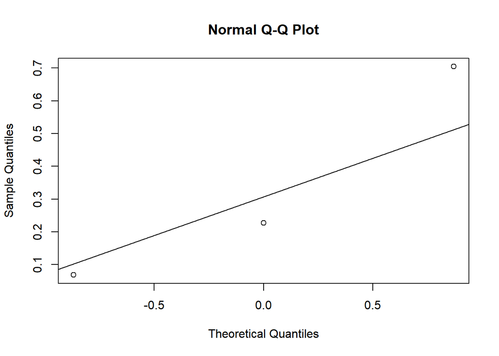

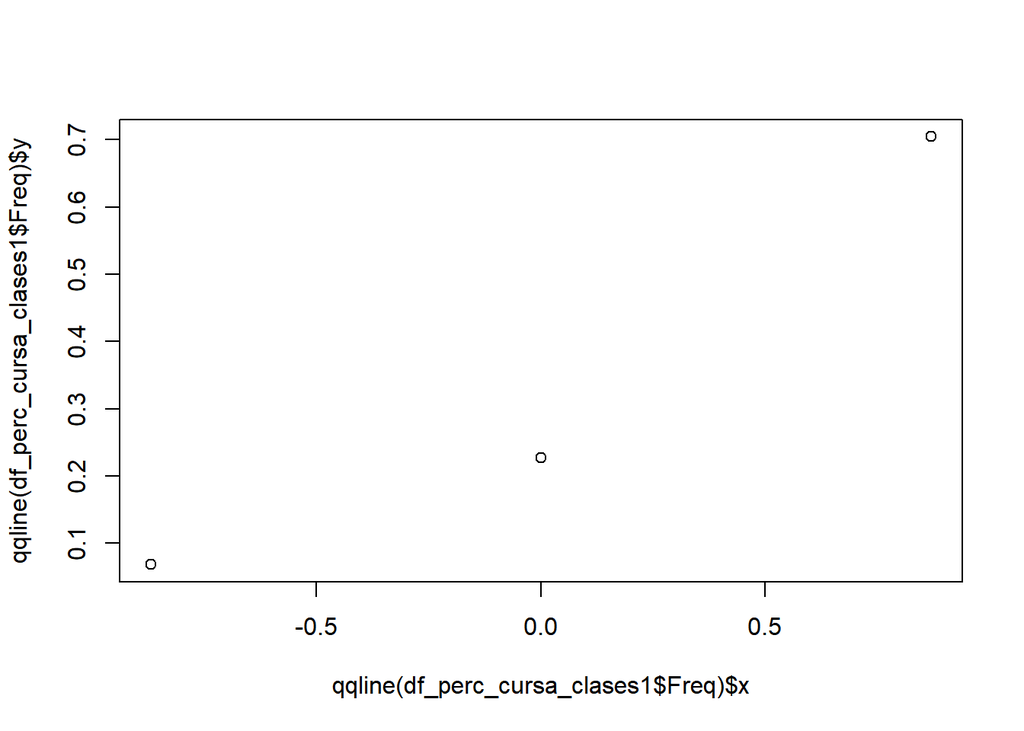

La figura anterior representa la normalidad de la distribución de los datos para esta variable, según el trazo de la línea y la distancia que existe entre los puntos y ella se determina el margen de error existente, de acuerdo a lo visualizado, vemos el primer punto izquierda a derecha que es el más cercano a la línea, este representa los estudiantes que no cursan clases durante hacen la práctica, el segundo se ve más alejado de la línea, representa a los estudiantes que si realizan práctica y cursan clases, al final se observa el punto más alejado, es el que representa los estudiantes que no realizan práctica profesional.

## 5. Correlaciones

De acuerdo a los tipos de variables capturadas para nuestro dataset, solo se pueden hacer correlaciones entre variables categóricas, ya que no hay variables de tipo numérico.

### A continuación se mostrarán algunas correlaciones.

5.1 Correlación entre rendimiento_academico y rechazo_en_entrevista: Con esta correlacion se pretende saber si el rendimiento academico influye en el rechazo o aceptacion para la practica

```
##
##                No        Si
##   Alto  0.8181818 0.1818182
##   Bajo  1.0000000 0.0000000
##   Medio 0.6250000 0.3750000
```

Como se puede observar el 81.81% los estudiantes que consideran que tienen un alto rendimiento académico, no han sido rechazados, versus los estudiantes con alto rendimiento académico que si han sido rechazados, son el 18.19%. Así mismo, el 100% de los estudiantes que consideran que su rendimiento académico es bajo, no han sido rechazados, pero también existe la posibilidad de que nunca se hayan sometido a una entevista laboral. Finalizando con los estudiantes que consideran que tinene un medio rendimiento académico, el 62.5% no ha sido rechazado, versus un 37.5% que si ha sido rechazado.

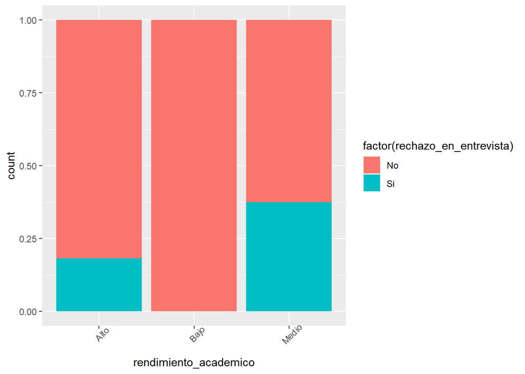

A continuación se plantean dos hipótesis para las correlaciones, una nula y la otra alternativa.

Hipótesis nula (Ho): las variables son independientes Hipótesis alternativa (Ho): las variables son dependientes

```
##
##  Pearson's Chi-squared test
##
## data:  table(survey$rendimiento_academico, survey$rechazo_en_entrevista)
## X-squared = 1.8857, df = 2, p-value = 0.3895
```

5.2 Correlación entre area_sistema_dificulta y rechazo_en_entrevista: Con esta correlacion se pretende saber si los estudiantes al tener dificultad en determinada área de la carrera influye en el rechazo o aceptacion para la practica

```
##              Var1       Freq
## 1      Desarrollo 0.43181818
## 2 Infraestructura 0.34090909
## 3   Base de datos 0.13636364
## 4    Electrónica  0.09090909
```

```
##
##                          No        Si
##   Base de datos   0.6666667 0.3333333
##   Desarrollo      0.6842105 0.3157895
##   Electrónica     1.0000000 0.0000000
##   Infraestructura 0.6000000 0.4000000
```

Como se puede observar en la tabla anterior, del porcentaje de estudiantes que se les dificulta el área de bases de datos, el 66.67% no ha sido rechazado en entrevistas, versus el 33.33% que si ha experimentado el rechazo.

Siguiendo, tenemos el porcentaje de estudiantes que se les dificulta el área de desarrollo, el 68.42% no ha sido rechazado en entrevistas, versus el 31.58% que si han sido rechazados.

Finalizando con los estudiantes que se les dificulta el área de infraestructura, el 60% de esta muestra, no ha sido rechazada, en comparación con el 40% que si ha sido rechazada.

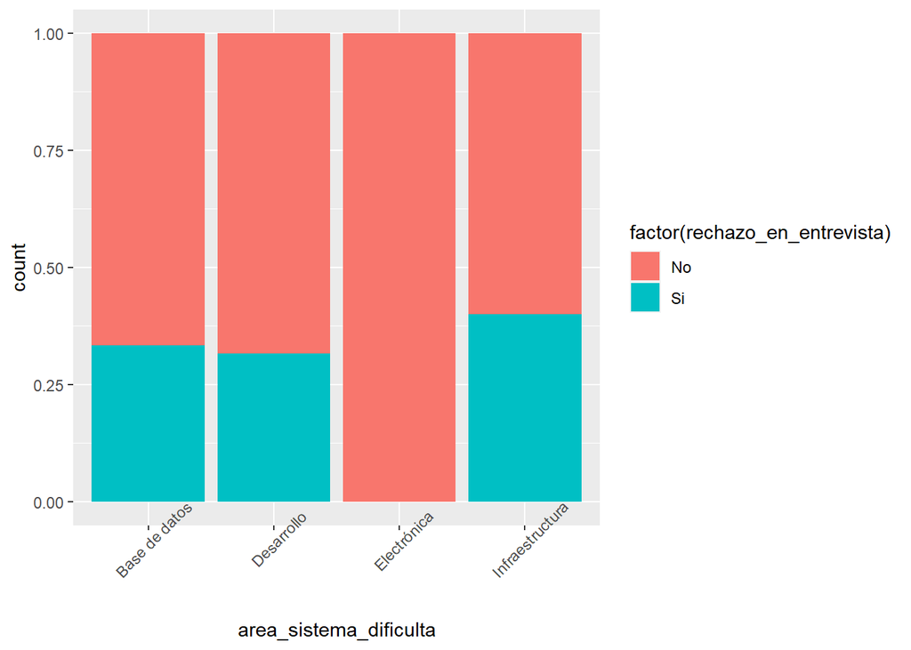

A continuación se plantean dos hipótesis para las correlaciones, una nula y la otra alternativa.

Hipótesis nula (Ho): las variables son independientes Hipótesis alternativa (Ho): las variables son dependientes

```
##
##  Pearson's Chi-squared test
##
## data:  table(survey$area_sistema_dificulta, survey$rechazo_en_entrevista)
## X-squared = 2.3364, df = 3, p-value = 0.5056
```

## 6. Análisis explicativo

### regresiones

Esta sección busca mostrar las razones o causas que den respuesta a la pregunta principal de investigacón, y asi tratar de explicar mediante la comprobación de la hipótesis planteada porqué ocurre este fenómeno.

```
##
##        No        Si
## 0.6818182 0.3181818
```

```
##        Overall                            colum
## 1  1.114816969             rango_indice81 o mas
## 2  0.950417029             estudiante_foraneoSi
## 3  0.369336089                rango_indice71-75
## 4  0.315905223                        trabajasi
## 5  0.313615635                rango_indice76-80
## 6  0.109279581                        edad26-30
## 7  0.010771042       rendimiento_academicoMedio
## 8  0.006338524                     edad31 o Mas
## 9  0.004360827 nuevas_habilidades_autodidactaSi
## 10 0.004133348        rendimiento_academicoBajo
```

```
##
## Call:  glm(formula = rechazo_en_entrevista ~ ., family = "binomial",
##     data = set)
##
## Coefficients:
##                      (Intercept)                         edad26-30
##                        -17.25562                           0.08084
##                     edad31 o Mas              estudiante_foraneoSi
##                        -16.94957                          -0.88395
##                        trabajasi                 rango_indice71-75
##                          0.23634                          -0.40349
##                rango_indice76-80              rango_indice81 o mas
##                         -0.32645                          -1.53909
##        rendimiento_academicoBajo        rendimiento_academicoMedio
##                        -16.35227                           0.01220
## nuevas_habilidades_autodidactaSi
##                         17.25222
##
## Degrees of Freedom: 43 Total (i.e. Null);  33 Residual
## Null Deviance:       55.04
## Residual Deviance: 48.4  AIC: 70.4
```

Ya recopilados las variables más influyentes ya ordenadas de la más importante a la menos importarte de acuerdo a la variable de respuesta como podemos ver la variable “Rango_indice” es la más influyente apareciendo en diversas ocasiones y teniendo la mayor importancias, para verlo de una manera más clara recopilaremos cada variable con sus respectivos gráficos.

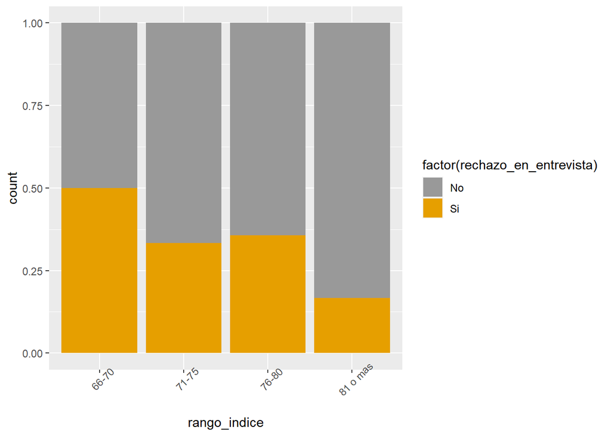

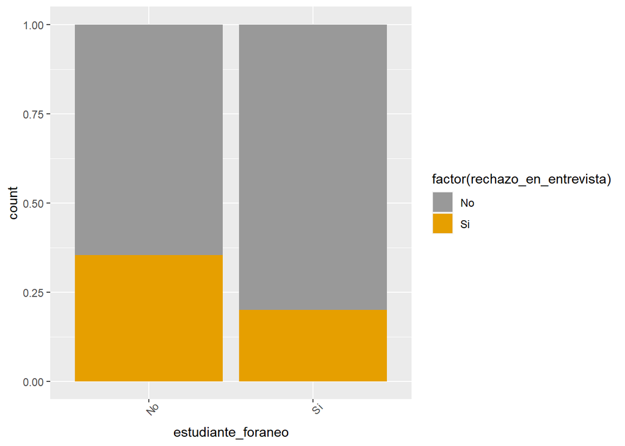

Logramos apreciar en el grafico anterior que los estudiantes que son foráneos tienen mayor aceptación en las entrevistas consiguiendo la aprobación de las empresas para realizar la practica profesional, las personas que son del interior del país no tienen problemas en encontrar una empresa en donde puedan hacer la practica a comparación a los estudiantes que viven en la capital ellos se demuestran que tienden a ser mas rechazados por las empresas.

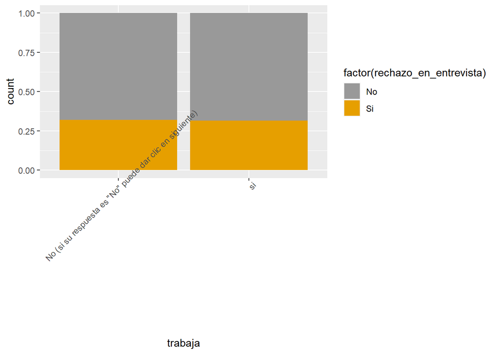

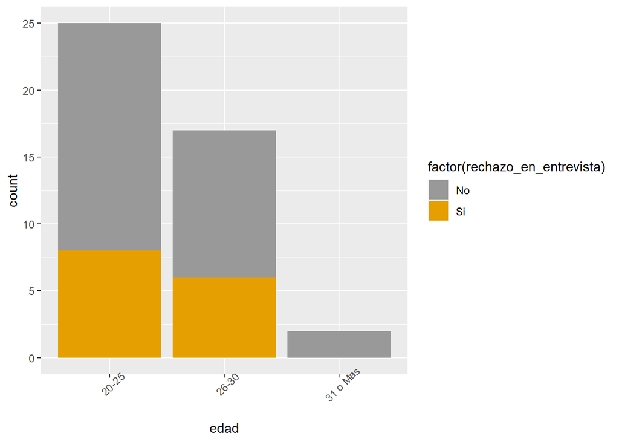

En el grafico anterior vemos que los estudiantes que tienen años de 20-25 tienen menos rechazo en las entrevistas por parte de las empresas, notamos las mismas circunstancias en la barra de las edades de 26-30, podemos decir que las empresas tienen una mayor aceptación a los estudiantes que están a una edad de 20 a 25 años además de que la mayoría de los encuestados son muy jóvenes dándoles más posibilidades de ser aceptados, pero a los estudiantes que tienen una edad de 26 a 30 no es tanta la aceptación a comparación con la barra anterior y la o el estúdiate con mayoría de edad tienen aceptación pero no podemos decir que la tiene o no, por la poca cantidad de datos en la ultima barra.

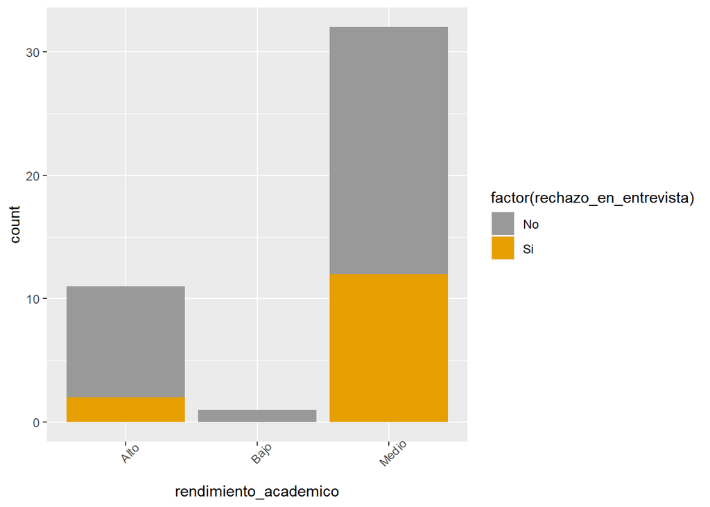

En el grafico anterior vemos con claridad que el estudiantado que tiene alto rendimiento académico obviamente consigue menos rechazo por parte de las empresas, notamos que el rendimiento medio del estudiantado es muy alto y también tienen un gran número de aceptación pero le sigue un número considerable de rechazo pero a pesar del número de rechazo el estudiantado consigue aceptación en algún momento.

## 7. Solución tecnológica

Con toda la informacion mostrada anteriormente, vemos como el problema de nuestro estudio necesita una solucion, para este caso en particular se propone una solucion basada en tecnologia a continuacion mostramos en que consite nuestra solucion:

[figure not shown]

Ilustración Arquitectura propuesta tecnológica Fuente: (Propia, Fuente Propia, 2020)

Esta solución tecnológica está diseñada y pensada para ser utilizada en diferentes plataformas y dispositivos a través de la web, esto nos da la facilidad y flexibilidad de llegar al mayor número de usuarios, simplificando costos y esfuerzo de desarrollo  
y así mismo ser un producto multiplataforma y multi sistema operativo, ya que únicamente se necesitara un explorador web y una conexión a internet. Buscamos que nuestro sistema sea de rápida implementación y fácilmente escalable, para un futuro crecimiento exponencial, ya que el área de nuestra investigación es una de las áreas más demandadas en el país, el área laboral. Para lograr esta escalabilidad, y obtener una fácil y rápida implementación destacamos el almacenamiento de información en la nube a través de amazon. Utilizando su gama de servicios en la nube de su plataforma online Amazon Web services junto los servicios de Amazon ML (Machine Learning).

#### Comunicación de servicios

[figure not shown]

Ilustración Arquitectura propuesta tecnológica Fuente: (Propia, Fuente Propia, 2020)

En este pequeño diagrama podemos ver como esta estructurado el servicio de acceso del usuario a el sistema, en este punto la interacción que buscamos es que sea de la manera mas sencilla posible para que cualquiera pueda tener acceso y sea de fácil uso, básicamente los requisitos para el usuario es contar con cualquier dispositivo que se conecte a internet y contar con una conexión de datos de internet, con esto logramos ser accesibles desde cualquier plataforma sin importar si es un dispositivo móvil , computadora, o sin importar el sistema operativo del usuario.

La funcionalidad de este servicio es básicamente lograr la interacción y recopilación de datos con el usuario, este diagrama en especifico si se presta una atención detallada al diagrama general se puede observar como se divide en 2 servicios, esto es porque un servicio será la interacción con las empresas que proveerán de datos de ofertas laborales al sistema, y el otro es la interacción del usuario que proveerá de datos de su perfil personal y sus preferencias personales al sistema, como se puede ver aunque son servicios que funcionaran por separado tienen la misma lógica aplicada en este diagrama en el cual podemos ver que la funcionalidad principal que buscamos con este servicio es la recolección de datos. Donde el usuario ingresa a la plataforma de Integración Empresarial a través de internet generando con esto una interacción entre el sitio web alojado en servidores web de amazon contra el api del backend también alojada en los servidores de la nube de Amazon, luego posterior mente el api servirá como intermedio entre los datos del usuario y la base de datos ya sea para almacenar la información ingresada por el usuario o para consultarla siendo la función principal del api servir o almacenar mediante la base de datos, información de relevancia para el usuario.

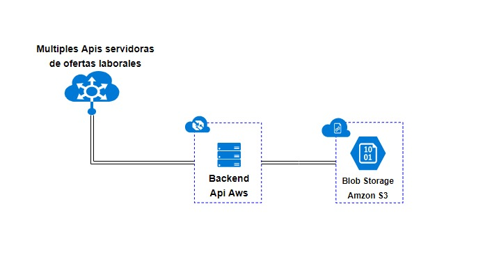

Servicio Recoleccion de ofertas de apis de terceros

En este diagrama queremos mostrar como tendremos un segundo servicio de recolección de datos para el área de ofertas laborales que estarán disponibles en nuestro sitio, como se menciono en la parte anterior existe un acceso para empresas que dotara de información de cv a nuestra base de datos, pero este puede que no sea siempre el caso, y si esto sucede dejaría prácticamente sin funcionalidad nuestra plataforma, para solucionar este problema y dotar de dinamismo nuestro sitio y que no dependa de alguien que alimente de ofertas laborales se implementa el servicio de recolección de data de Apis de terceros, este consistirá en básicamente consultar sitios web que tengan ofertas laborales y obtener estos datos en una comunicación directa entre nuestra api y las Apis de terceros donde nuestra api hará peticiones a las Apis de terceros recolectando así estas ofertas laborales , y buscando estructurar esta información para almacenarla en nuestra base de datos. En caso de que esta información obtenida no sea de forma estructurada ya que puede venir de archivos de texto, pdf, archivos json etc, nuestra api lo que hará con esta información no estructurada será almacenarla tal cual la encontró en el almacenamiento de amazon S3 o blob storage donde esto nos permitirá ser accedida mas adelante para darle un tratamiento especial a estos datos para luego mostrar estos al usuario. El objetivo principal que buscamos con este servicio claramente es la recopilación de la mayor cantidad de ofertas laborales para tener una gran variedad de opciones en nuestra data y que este así disponible para nuestros usuarios.

[figure not shown]

Servicio deAmazon ML (Machine Learning)

la base de nuestro sistema serán las recomendaciones , pero no queremos que sean cualquier tipo de recomendaciones de forma aleatoria, queremos lograr que nuestro sistema tenga un plus, y para esto queremos sacar ventajas del machine learning. Los sistemas de recomendación de contenidos se han hecho muy populares en los últimos años. Entre los ámbitos más extendidos se encuentran las recomendaciones de productos en tiendas online, películas, vídeos, música, libros, productos o recomendaciones de perfiles. Los Sistemas de Recomendación intentan personalizar al máximo lo que ofrecerán a cada usuario. A nivel de nuestra arquitectura se puede observar el servicio de ML (Machine Learning), y atraves de estos servicios que ofrece amazon web services de ML (Machine Learning), queremos llegar a lograr este objetivo, ya que con estas soluciones que nos ofrece esta empresa es mucho más fácil, rápido y menos costoso implementar este tipo de sistemas aprovechando las herramientas de ML (Machine Learning) que amazon pone a nuestro alcance esto se hace posible. Como podemos observar en nuestra arquitectura para llegar a este servicio en especifico hacemos un flujo de recolección de datos previamente para así crear nuestro dataSet que puede ser de datos estructurados (sql) almacenados en la base de datos o datos no estrucurados(pdf,texto,json..etc) que estarian almacenados en el blob storage y asi dotar de la información valiosa y necesaria a nuestro servicio de ML (Machine Learning) para así poder trabajar estos datos. Con todo esto lograríamos exprimir estas ventajas de ML (Machine Learning), y así lograr un sistema de recomendación afinado para nuestro caso de estudio donde gestionaríamos nuestro Collaborative Filtering, pues utiliza la información de «masas» para identificar perfiles similares y aprender de los datos para recomendar productos de manera individual en nuestro caso ofertas laborales personalizadas.

[figure not shown]

Servicio de notificaciones al usaurio

En este pequeño diagrama podemos ver como está estructurado el servicio de notificaciones al usuario, este servicio básicamente, funcionara mediante la comunicación de correo electrónico y esta se lograra gracias a otra de las opciones que nos brinda la plataforma de amazon en la nube que es el Amazon Simple Email Service (ASES). El objetivo general de este servicio es comunicar al usuario de ofertas laborales que pueden ser de su interés, pero este servicio en específico para nuestro sistema lo hemos dividido en dos partes a nivel de funcionalidad. La primera parte es donde buscamos trabajar por el estudiante de la UNAH mucho antes de que el incluso separa que esta herramienta en línea existe, esto lo logramos comunicando nuestra api directamente con la api de la universidad (UNAH) donde de ellos obtendremos únicamente el correo institucional, siendo esta una información que la unah provee de forma publica a los maestros todos los periodos, nosotros la solicitaremos a través de nuestra api únicamente de los estudiantes que tengan la característica o que estén catalogados por la UNAH como estudiantes por egresar , enviando así ofertas laborales almacenadas en nuestro sistema como mostramos en los diagramas previos, y que sean del interés del estudiante acorde a su área de estudio directamente a su correo electrónico. La segunda parte de esta es que si un estudiante le parece interesante la información que está recibiendo a través de su correo electrónico mediante nuestra plataforma, puede acceder a este y registrarse como un usuario, llenar su perfil, detallando sus intereses personales y laborales, luego nuestro sistema analizaría sus datos y mediante ML (Machine Learning), buscaríamos para este la oferta laborales que mas se ajusten a su perfil mediante el sistemas de recomendación de perfiles laborales, siendo este estudiante nuevamente notificado mediante correo electrónico y mostrándole asi que se encontró una coincidencia para su perfil.